# 문제 1

## import module

```python
import numpy as np
import pandas as pd
import sklearn
import matplotlib.pyplot as plt
```

## data

### Get data

```python
from sklearn.datasets import fetch_openml

mnist = fetch_openml('mnist_784', as_frame=False)
```

### Check Data

```python
X = mnist.data
Y = mnist.target
```

```python
X.shape, Y.shape
```

```
((70000, 784), (70000,))
```

```python
np.unique(Y)
```

```
array(['0', '1', '2', '3', '4', '5', '6', '7', '8', '9'], dtype=object)
```

### Check Image

```python
# 28x28 모양의 2차원 어레리로 변환 후 이미지 그리기
def plot_digit(image_data):
    image = image_data.reshape(28, 28)
    plt.imshow(image, cmap="binary")
    plt.axis("off")
```

- 첫째 이미지 확인

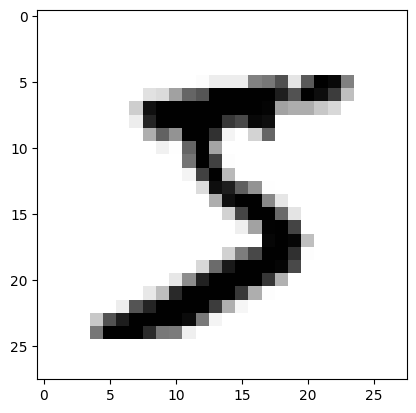

```python
some_digit = X[0]
plot_digit(some_digit)

plt.axis("on")
plt.show()
```

첫째 이미지의 실제 레이블 또한 5이다.

```python
Y[0]
```

```
'5'
```

처음 100개의 이미지는 다음과 같다.

- `plt.subplot()` 함수: 여러 개의 이미지를 격자 무늬의 공간에 하나씩 채울 수 있도록 위치를 지정함.

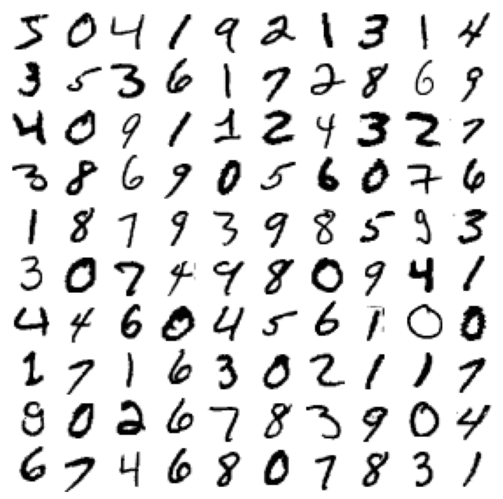

```python
plt.figure(figsize=(9, 9))

# 10x10 모양의 이미지 모음. plt.subplot 활용
for idx, image_data in enumerate(X[:100]):
    plt.subplot(10, 10, idx + 1)
    plot_digit(image_data)

plt.subplots_adjust(wspace=0, hspace=0)
plt.show()
```

**훈련셋과 테스트셋**

불러온 데이터셋은 이미 6:1 의 비율로 훈련셋과 데이터셋으로 분류된 상태로 제공되며 여기서도 그대로 이용한다.

```python
X_train, X_test, Y_train, Y_test = X[:60000], X[60000:], Y[:60000], Y[60000:]
```

### 문제1. 정확도 97% 성능의 MNIST 분류기

테스트셋에 대한 정확도가 97% 이상 나오는 MNIST 분류기를 학습시킨다.

힌트: `KNeighborsClassifier` 클래스가 꽤 잘 훈련된다. 대신 그리드 탐색을 이용하여 적절한 `weights`와 `n_neighbors` 하이퍼파라미터를 찾아야 한다.

```python
from sklearn.neighbors import KNeighborsClassifier
```

#### KNeighborsClassifier

[figure not shown]

K-Nearest Neighbors (KNN) 알고리즘을 분류에 적용한 모델  
분류 기법 중 하나이며 특정 새 데이터를 새로운 카테고리에 넣을 때 가장 가까운 카테고리(이웃; `neighbor`)에 포함시키도록 하는 방식  
거리 계산 방식에는 유클리드 or 맨해튼 방식을 가장 많이 씀

- 유클리드: 두 점 사이 가장 가까운 거리
- 맨해튼: x축, y축 격자를 따라 가장 가까운 거리

```python
knn_clf = KNeighborsClassifier()
knn_clf.fit(X_train, Y_train)
baseline_accuracy = knn_clf.score(X_test, Y_test)
baseline_accuracy
```

```
0.9688
```

```python
from sklearn.model_selection import GridSearchCV

param_grid = [{'weights': ["uniform", "distance"], 'n_neighbors': [3, 4, 5, 6]}]

knn_clf = KNeighborsClassifier()
grid_search = GridSearchCV(knn_clf, param_grid, cv=5)
grid_search.fit(X_train[:10_000], Y_train[:10_000])
```

```
GridSearchCV(cv=5, estimator=KNeighborsClassifier(),
             param_grid=[{'n_neighbors': [3, 4, 5, 6],
                          'weights': ['uniform', 'distance']}])
```

- weights: ["uniform", "distance"]
  - `uniform`*(모든 neighbor에 같은 가중치 부여)*, `distance`*(거리에 반비례하는 가중치를 부여 - 거리가 멀수록 중요도를 낮게 판단)* 의 조합으로 시도함
- n_neighbors: [3,4,5,6]
  - neighbor의 수를 3~6으로 한번씩 시도함

> -> 2 x 4 = 8 가지 조합으로 시도됨
- cv: 5
  - 5-fold 교차 검증을 수행 -> 데이터를 5개 부분으로 나누어 4개 학습, 1개 검증하는 과정을 5번 반복

> -> 총 2 x 4 x 5 = 40 가지 조합으로 시도됨

```python
grid_search.best_params_
```

```
{'n_neighbors': 4, 'weights': 'distance'}
```

```python
grid_search.best_score_
```

```
np.float64(0.9441999999999998)
```

성능이 떨어졌지만 이는 적은 훈련셋을 이용했기 때문이다. 그런데 찾은 최적의 모델을 전체 훈련셋에 대해 다시 훈련한 다음에 테스텟에 대한 정확도를 확인하면 97% 이상이 나온다.

> 최적의 param {'n_neighbors': 4, 'weights': 'distance'}

> 최적의 score 0.944199...

```python
grid_search.best_estimator_.fit(X_train, Y_train)
tuned_accuracy = grid_search.score(X_test, Y_test)
tuned_accuracy
```

```
0.9714
```